# Biostats625_Final_Report

Group Project

2024-12-17

## Introduction

Diabetes is a widespread health issue, affecting millions of individuals worldwide and leading to high medical expenses over time. The idea behind our project was to see whether we could build strong and efficient machine learning models to predict diabetes using demographic and health-related data. At first, we experimented with a smaller Heart Disease dataset (303 entries). Although it helped us get started, we quickly realized it wasn’t large enough to show the challenges of running machine learning at a much bigger scale. Because of that, we turned to the CDC Diabetes Health Indicators dataset, which has more than 250,000 records. Handling so many rows pushed us to rely on parallel computing, memory-friendly data formats, and special algorithmic tweaks to train models in a reasonable time.

## Methods

### K-Nearest Neighbors

We initially picked K-Nearest Neighbors (KNN) for its simplicity, but it quickly became obvious that naive distance computations across hundreds of thousands of rows took a lot of time and memory. We decided to reduce dimensionality by applying PCA for numeric features and MCA for binary ones, dropping from 20 to 9 dimensions. Then, we rewrote the distance function in C++ and used partial sorting (nth_element) so we only sorted the top k neighbors instead of sorting all distances. We also parallelized the test set predictions through parLapply by processing 1,000 test samples per chunk. These changes brought runtime down from 85 seconds to 32 seconds (a ~62% speedup). KNN ended up at about 72% accuracy once we optimized it heavily.

### Logistic Regression

Logistic Regression was our interpretable baseline. The probability of having diabetes is:
$$\begin{equation}
P(Y=1|X) = \frac{1}{1 + e^{-(\beta_0 + \sum_{i=1}^p \beta_i X_i)}}
\end{equation}$$
Given the number of features and rows, we used elastic net regularization to stabilize coefficient estimates:
$$\begin{equation}
\min_{\beta_0, \beta} \left[-\sum_{i=1}^n \log(P(y_i|x_i)) +
\lambda(\alpha||\beta||_1 + \frac{1-\alpha}{2}||\beta||_2^2)\right]
\end{equation}$$
Cross-validation for such a big dataset was time-consuming, so we applied parallelization (doParallel) to divide the folds among CPU cores. Final accuracy was ~70%. Even though it wasn’t the top performer, logistic regression was more interpretable and faster than KNN once we parallelized cross-validation.

### Decision Tree

We trained a single Decision Tree using rpart. This was fairly quick to run, even for a large dataset, because trees split data greedily. We performed a grid search over the complexity parameter (cp) from 0.0005 to 0.02. Parallel backends also helped speed up the cross-validation for those cp values. While the final accuracy was ~68%, the decision tree was extremely easy to interpret and required the least computational effort compared to more advanced methods.

### Random Forest

Random Forest combines multiple bootstrapped decision trees to create a more robust classifier. Initially, we tried the standard randomForest package, which was quite slow. We switched to ranger, a much faster implementation that supports multi-threading. Training time plummeted from 362 seconds to about 3.42 seconds, and final accuracy reached 74.81% (AUC ~0.8263). This showed us how switching libraries and using multi-threaded methods can drastically cut down runtime on large datasets.

### Interest and Aim

All of these methods are aimed at early diabetes detection, which can help people manage their condition and reduce complications. The global burden of diabetes keeps growing, and building an accurate yet efficient model can be a stepping stone for better screening tools. Our real focus was not just on accuracy but also on how to handle the computational challenges of a massive dataset (over 250k rows). Each method—KNN, Logistic Regression, Decision Tree, Random Forest, and XGBoost—required some combination of parallelization, sparse data usage, or algorithmic changes (like partial sorting in C++ for KNN) to make the training feasible.

Results Below is some R code comparing the final accuracies of our models in a single plot:

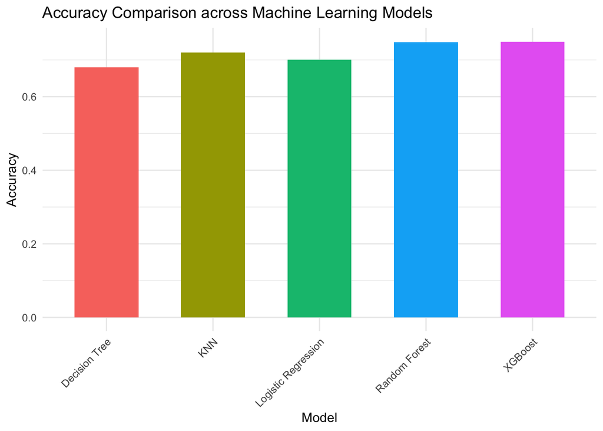

```r
library(ggplot2)

model_accuracy <- data.frame(
  Model    = c("Logistic Regression", "KNN", "Decision Tree", "Random Forest", "XGBoost"),
  Accuracy = c(0.70, 0.72, 0.68, 0.7481, 0.75)
)

ggplot(model_accuracy, aes(x = Model, y = Accuracy, fill = Model)) +
  geom_bar(stat = "identity", width = 0.6) +
  labs(
    title = "Accuracy Comparison across Machine Learning Models",
    x = "Model",
    y = "Accuracy"
  ) +
  theme_minimal() +
  theme(
    axis.text.x = element_text(angle = 45, hjust = 1),
    legend.position = "none"
  )
```

## Conclusion

Our project demonstrated that advanced optimization strategies—like parallel cross-validation, sparse representations, chunk-based processing, and partial sorting—are crucial for handling large-scale diabetes data efficiently. Even classic models (like KNN or Logistic Regression) can be sped up drastically if we use the right libraries and parallelization. Random Forest (ranger) and XGBoost performed the best, achieving about 75% accuracy and AUC around 0.82, all while training in seconds or minutes instead of hours. We plan to expand our benchmark comparisons to systematically time each method under various parallel or sparse settings so that future healthcare applications can balance speed, memory usage, and accuracy in the quest for early diabetes detection.